# The Effectiveness of Three-Dimensional Technology in Medical education and Training A Data scientist approach

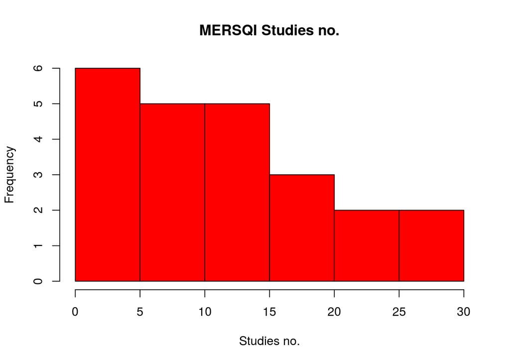

```r
hist(MERSQI$`Studies no.`, main = paste("MERSQI Studies no."), col="red", xlab="Studies no.")
```

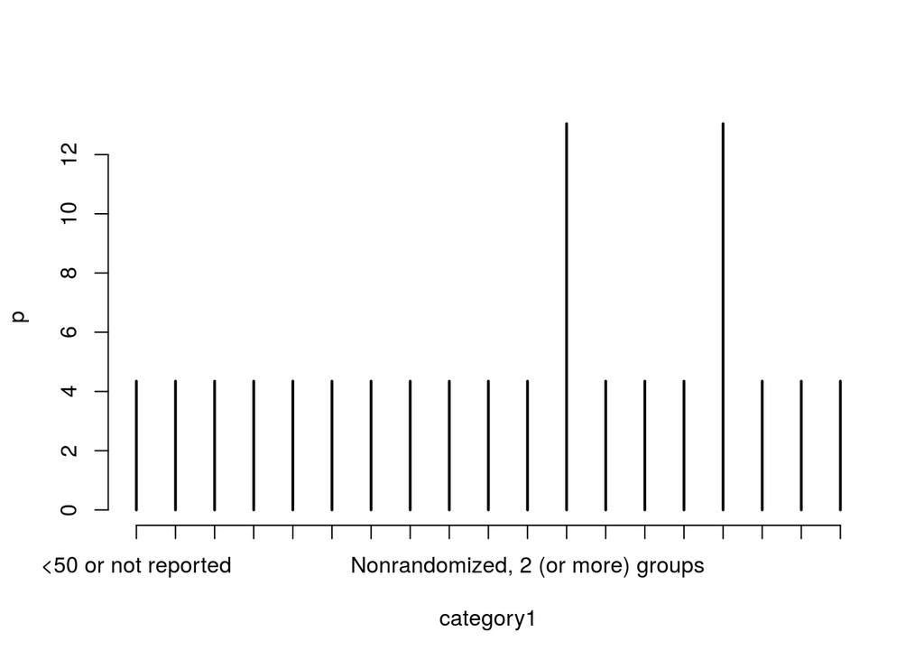

```
##                                                              [,1]      [,2]
## <50 or not reported                                             1  4.347826
## ≥75                                                             1  4.347826
## 50–74                                                           1  4.347826
## Assessment by study participant (e.g., selfreported data)       1  4.347826
## Behaviours (e.g., physician actual practice)                    1  4.347826
## Beyond descriptive analysis (any comparisons)                   1  4.347826
## Data analysis appropriate for study design and type of data     1  4.347826
## Data analysis inappropriate for study design or type of data    1  4.347826
## Descriptive analysis only (means and variances)                 1  4.347826
## Knowledge, skills (e.g., OSCEs, SPs as outcome measure)         1  4.347826
## Nonrandomized, 2 (or more) groups                               1  4.347826
## Objective measurement (e.g., OSCE, written exam)                1  4.347826
## Patient/health care outcomes                                    1  4.347826
## Randomized controlled trial                                     1  4.347826
## Satisfaction, attitude, perceptions, opinion, general facts.    1  4.347826
## Single group crosssectional or single group posttest only       1  4.347826
## Single group pretest and posttest                               1  4.347826
## Not reported                                                    3 13.043478
## Reported                                                        3 13.043478
##                                                              [,3]
## <50 or not reported                                             2
## ≥75                                                             2
## 50–74                                                           2
## Assessment by study participant (e.g., selfreported data)       2
## Behaviours (e.g., physician actual practice)                    2
## Beyond descriptive analysis (any comparisons)                   2
## Data analysis appropriate for study design and type of data     2
## Data analysis inappropriate for study design or type of data    2
## Descriptive analysis only (means and variances)                 2
## Knowledge, skills (e.g., OSCEs, SPs as outcome measure)         2
## Nonrandomized, 2 (or more) groups                               2
## Objective measurement (e.g., OSCE, written exam)                2
## Patient/health care outcomes                                    2
## Randomized controlled trial                                     2
## Satisfaction, attitude, perceptions, opinion, general facts.    2
## Single group crosssectional or single group posttest only       2
## Single group pretest and posttest                               2
## Not reported                                                    2
## Reported                                                        2
```

```r
CountPerc(MERSQI$`MERSQI item`)
```

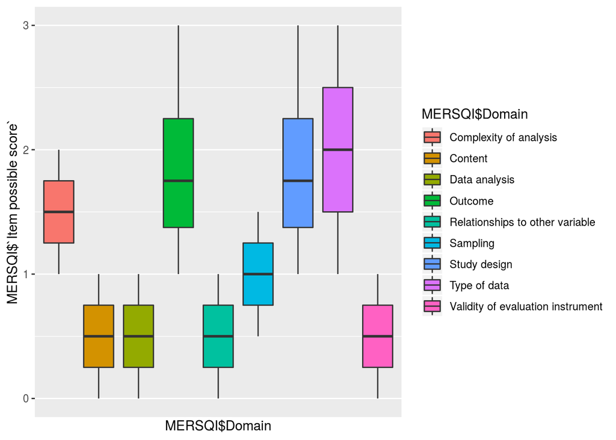

```r
ggplot(MERSQI, aes(MERSQI$Domain,MERSQI$`Item possible score`))+geom_boxplot(aes(fill=MERSQI$Domain))+scale_x_discrete(breaks=levels(MERSQI$Domain))
```

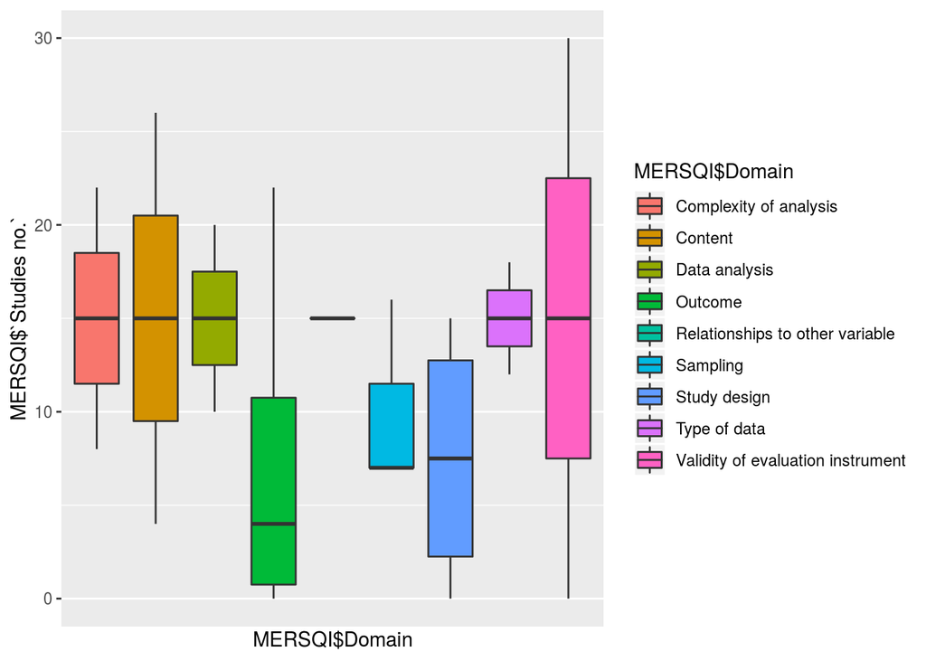

```r
ggplot(MERSQI, aes(MERSQI$Domain,MERSQI$`Studies no.`))+geom_boxplot(aes(fill=MERSQI$Domain))+scale_x_discrete(breaks=levels(MERSQI$Domain))
```

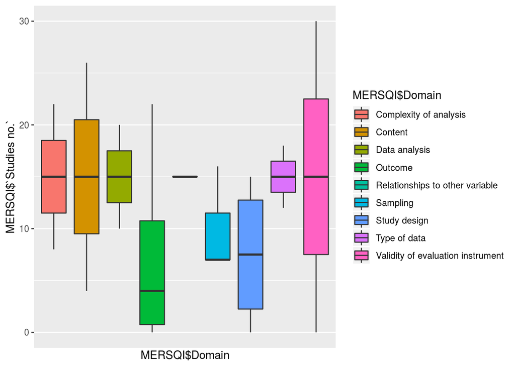

```r
ggplot(MERSQI, aes(MERSQI$Domain,MERSQI$`Studies no.`))+geom_boxplot(aes(fill=MERSQI$Domain))+scale_x_discrete(breaks=levels(MERSQI$Domain))
```

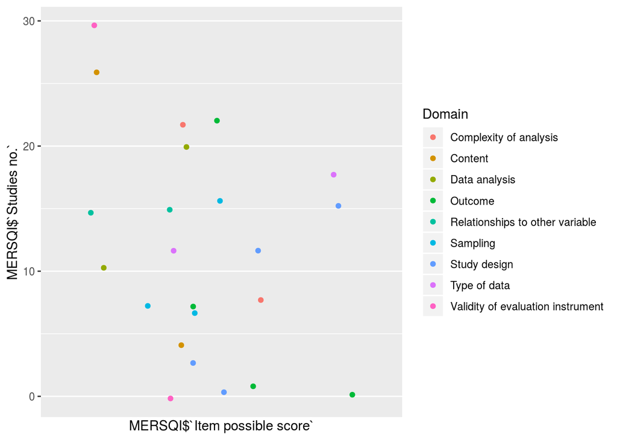

```r
ggplot(MERSQI, aes(MERSQI$`Item possible score`,MERSQI$`Studies no.`))+ geom_jitter(aes(color=Domain))+scale_x_discrete(breaks=levels(MERSQI$Domain))
```

#MEDICAL COLLEGES AND 3D MEDICAL EDUCATION Data was gathered by searching NSF database for medical college statistics and searching the internet for college medical 3D education or research. Some data was taken from university sites and articles. Data includes : total medical R & D expenditure, Medical School, and the number of students who used the technology among others. # MEDICAL COLLEGES AND 3D MEDICAL EDUCATION: SUMMARY: Investigate the distribution of 3d tech and R &D expenditure

```r
Descriptive_analysis(X3D_Med)
```

```
## Classes 'tbl_df', 'tbl' and 'data.frame':    24 obs. of  10 variables:
##  $ College Name                                          : chr  "Harvard" "Johns Hopkins" "New York" "Stanford" ...
##  $ Private or Public Institution                         : chr  "Private" "Private" "Private" "Private" ...
##  $ No. of med students                                   : num  715 485 531 482 607 595 727 494 486 643 ...
##  $ Teaching Hosipital                                    : chr  "Yes" "Yes" "Yes" "Yes" ...
##  $ Medical R &D expenditures(National Science Foundation): chr  "251,869" "$663,549" "551,298" "686,073" ...
##  $ Uses 3D Tech to treats mental diseases                : chr  "Yes" "Yes" "Yes" "Yes" ...
##  $ Most Analyzed 3D Model of an Organ                    : chr  "Brain" "Lung" "Brain" "Brain" ...
##  $ Types of 3D technology                                : chr  "Bioprinting,Imaging,AR/VR,modeling" "Bioprinting,Imaging,AR/VR,modeling" "Bioprinting,Imaging,AR/VR,modeling" "Bioprinting,Imaging,AR/VR,modeling" ...
##  $ Most cited printed organ                              : chr  "heart" "kidney" "heart" "liver" ...
##  $ Total R&D                                             : num  1077253 2431180 809739 1066269 1294261 ...
##  - attr(*, "spec")=List of 2
##   ..$ cols   :List of 10
##   .. ..$ College Name                                          : list()
##   .. .. ..- attr(*, "class")= chr  "collector_character" "collector"
##   .. ..$ Private or Public Institution                         : list()
##   .. .. ..- attr(*, "class")= chr  "collector_character" "collector"
##   .. ..$ No. of med students                                   : list()
##   .. .. ..- attr(*, "class")= chr  "collector_number" "collector"
##   .. ..$ Teaching Hosipital                                    : list()
##   .. .. ..- attr(*, "class")= chr  "collector_character" "collector"
##   .. ..$ Medical R &D expenditures(National Science Foundation): list()
##   .. .. ..- attr(*, "class")= chr  "collector_character" "collector"
##   .. ..$ Uses 3D Tech to treats mental diseases                : list()
##   .. .. ..- attr(*, "class")= chr  "collector_character" "collector"
##   .. ..$ Most Analyzed 3D Model of an Organ                    : list()
##   .. .. ..- attr(*, "class")= chr  "collector_character" "collector"
##   .. ..$ Types of 3D technology                                : list()
##   .. .. ..- attr(*, "class")= chr  "collector_character" "collector"
##   .. ..$ Most cited printed organ                              : list()
##   .. .. ..- attr(*, "class")= chr  "collector_character" "collector"
##   .. ..$ Total R&D                                             : list()
##   .. .. ..- attr(*, "class")= chr  "collector_number" "collector"
##   ..$ default: list()
##   .. ..- attr(*, "class")= chr  "collector_guess" "collector"
##   ..- attr(*, "class")= chr "col_spec"
```

```
##  [1] "College Name"
##  [2] "Private or Public Institution"
##  [3] "No. of med students"
##  [4] "Teaching Hosipital"
##  [5] "Medical R &D expenditures(National Science Foundation)"
##  [6] "Uses 3D Tech to treats mental diseases"
##  [7] "Most Analyzed 3D Model of an Organ"
##  [8] "Types of 3D technology"
##  [9] "Most cited printed organ"
## [10] "Total R&D"
```

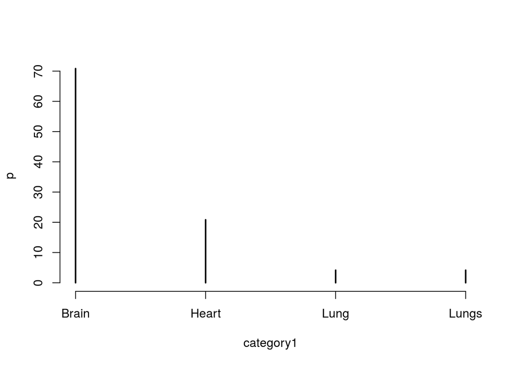

```
##       [,1]      [,2] [,3]
## Lung     1  4.166667    2
## Lungs    1  4.166667    2
## Heart    5 20.833333    2
## Brain   17 70.833333    2
```

```r
CountPerc(X3D_Med$`Most Analyzed 3D Model of an Organ`)
```

```r
(summary(X3D_Med$`College Name`))
```

```
##    Length     Class      Mode
##        24 character character
```

```r
str(X3D_Med)
```

```
## Classes 'tbl_df', 'tbl' and 'data.frame':    24 obs. of  10 variables:
##  $ College Name                                          : chr  "Harvard" "Johns Hopkins" "New York" "Stanford" ...
##  $ Private or Public Institution                         : chr  "Private" "Private" "Private" "Private" ...
##  $ No. of med students                                   : num  715 485 531 482 607 595 727 494 486 643 ...
##  $ Teaching Hosipital                                    : chr  "Yes" "Yes" "Yes" "Yes" ...
##  $ Medical R &D expenditures(National Science Foundation): chr  "251,869" "$663,549" "551,298" "686,073" ...
##  $ Uses 3D Tech to treats mental diseases                : chr  "Yes" "Yes" "Yes" "Yes" ...
##  $ Most Analyzed 3D Model of an Organ                    : chr  "Brain" "Lung" "Brain" "Brain" ...
##  $ Types of 3D technology                                : chr  "Bioprinting,Imaging,AR/VR,modeling" "Bioprinting,Imaging,AR/VR,modeling" "Bioprinting,Imaging,AR/VR,modeling" "Bioprinting,Imaging,AR/VR,modeling" ...
##  $ Most cited printed organ                              : chr  "heart" "kidney" "heart" "liver" ...
##  $ Total R&D                                             : num  1077253 2431180 809739 1066269 1294261 ...
##  - attr(*, "spec")=List of 2
##   ..$ cols   :List of 10
##   .. ..$ College Name                                          : list()
##   .. .. ..- attr(*, "class")= chr  "collector_character" "collector"
##   .. ..$ Private or Public Institution                         : list()
##   .. .. ..- attr(*, "class")= chr  "collector_character" "collector"
##   .. ..$ No. of med students                                   : list()
##   .. .. ..- attr(*, "class")= chr  "collector_number" "collector"
##   .. ..$ Teaching Hosipital                                    : list()
##   .. .. ..- attr(*, "class")= chr  "collector_character" "collector"
##   .. ..$ Medical R &D expenditures(National Science Foundation): list()
##   .. .. ..- attr(*, "class")= chr  "collector_character" "collector"
##   .. ..$ Uses 3D Tech to treats mental diseases                : list()
##   .. .. ..- attr(*, "class")= chr  "collector_character" "collector"
##   .. ..$ Most Analyzed 3D Model of an Organ                    : list()
##   .. .. ..- attr(*, "class")= chr  "collector_character" "collector"
##   .. ..$ Types of 3D technology                                : list()
##   .. .. ..- attr(*, "class")= chr  "collector_character" "collector"
##   .. ..$ Most cited printed organ                              : list()
##   .. .. ..- attr(*, "class")= chr  "collector_character" "collector"
##   .. ..$ Total R&D                                             : list()
##   .. .. ..- attr(*, "class")= chr  "collector_number" "collector"
##   ..$ default: list()
##   .. ..- attr(*, "class")= chr  "collector_guess" "collector"
##   ..- attr(*, "class")= chr "col_spec"
```

```r
Two_way_tables(X3D_Med$`Most Analyzed 3D Model of an Organ`,X3D_Med$`Types of 3D technology`)
```

```
##                      X^2 df P(> X^2)
## Likelihood Ratio 0.70744  3  0.87145
## Pearson          0.42967  3  0.93405
##
## Phi-Coefficient   : NA
## Contingency Coeff.: 0.133
## Cramer's V        : 0.134
```

```r
Two_way_tables(X3D_Med$`Most Analyzed 3D Model of an Organ`,X3D_Med$`Most cited printed organ`)
```

```
##                     X^2 df P(> X^2)
## Likelihood Ratio 9.5500  6  0.14493
## Pearson          8.9815  6  0.17462
##
## Phi-Coefficient   : NA
## Contingency Coeff.: 0.522
## Cramer's V        : 0.433
```

#MEDICAL COLLEGES AND 3D MEDICAL EDUCATION STATS AND MODELING

```r
Two_way_tables(X3D_Med$`Private or Public Institution`,X3D_Med$`Types of 3D technology`)
```

```
##                     X^2 df P(> X^2)
## Likelihood Ratio 1.4298  2  0.48924
## Pearson          1.0435  2  0.59349
##
## Phi-Coefficient   : NA
## Contingency Coeff.: 0.204
## Cramer's V        : 0.209
```

```r
correlation(X3D_Med$`Total R&D`,X3D_Med$`No. of med students`)
```

```
## [1] -0.05414299
```

```r
#STats
mean(sort(X3D_Med$`Total R&D`))
```

```
## [1] 937827.3
```

```r
median(sort(X3D_Med$`Total R&D`))
```

```
## [1] 885779
```

```r
v<-X3D_Med$`Total R&D`/X3D_Med$`Total R&D`
v
```

```
##  [1] 1 1 1 1 1 1 1 1 1 1 1 1 1 1 1 1 1 1 1 1 1 1 1 1
```

```r
#3d tech and R &D expenditure by college
lm1<-lm (X3D_Med$`Total R&D`~ X3D_Med$`Private or Public Institution`)
summary(lm1)
```

```
##
## Call:
## lm(formula = X3D_Med$`Total R&D` ~ X3D_Med$`Private or Public Institution`)
##
## Residuals:
##     Min      1Q  Median      3Q     Max
## -558028 -270034  -44758  164718 1526883
##
## Coefficients:
##                                                 Estimate Std. Error t value
## (Intercept)                                       904297     131191   6.893
## X3D_Med$`Private or Public Institution`Private    151481     473017   0.320
## X3D_Med$`Private or Public Institution`Public      59386     189702   0.313
##                                                 Pr(>|t|)
## (Intercept)                                     8.22e-07 ***
## X3D_Med$`Private or Public Institution`Private     0.752
## X3D_Med$`Private or Public Institution`Public      0.757
## ---
## Signif. codes:  0 '***' 0.001 '**' 0.01 '*' 0.05 '.' 0.1 ' ' 1
##
## Residual standard error: 454500 on 21 degrees of freedom
## Multiple R-squared:  0.00795,    Adjusted R-squared:  -0.08653
## F-statistic: 0.08414 on 2 and 21 DF,  p-value: 0.9196
```

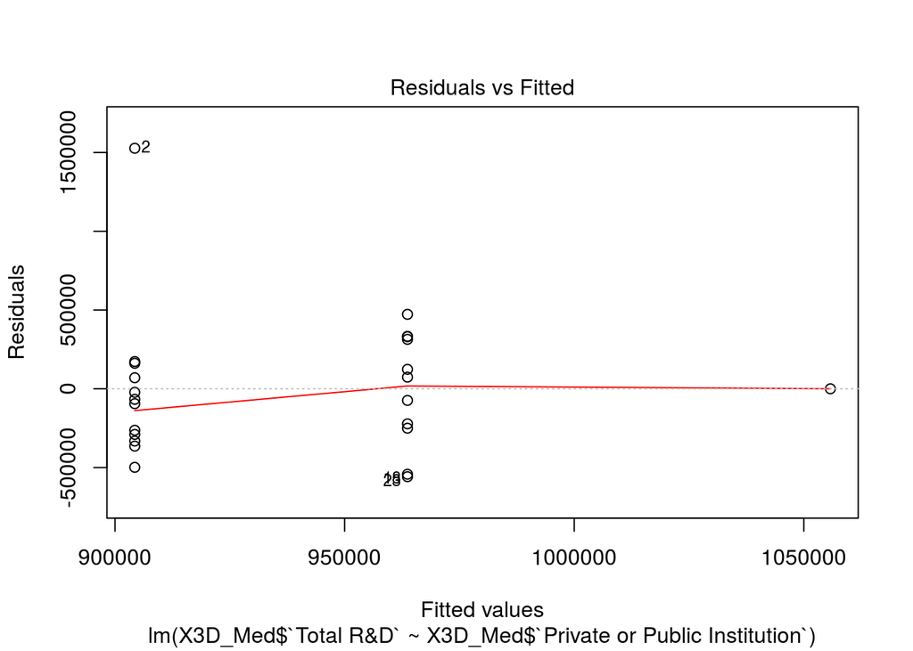

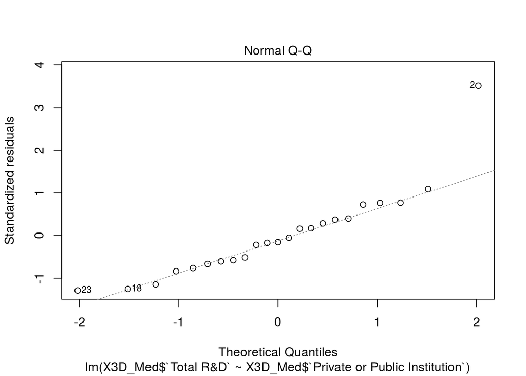

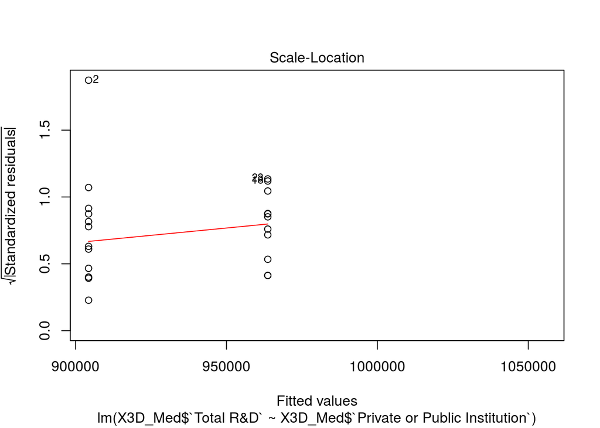

```r
plot(lm1)
```

[figure not shown]

```r
abline()
```

```r
#other variables
lm1b<-lm (X3D_Med$`Total R&D`~X3D_Med$`Private or Public Institution`)
summary(lm1b)
```

```
##
## Call:
## lm(formula = X3D_Med$`Total R&D` ~ X3D_Med$`Private or Public Institution`)
##
## Residuals:
##     Min      1Q  Median      3Q     Max
## -558028 -270034  -44758  164718 1526883
##
## Coefficients:
##                                                 Estimate Std. Error t value
## (Intercept)                                       904297     131191   6.893
## X3D_Med$`Private or Public Institution`Private    151481     473017   0.320
## X3D_Med$`Private or Public Institution`Public      59386     189702   0.313
##                                                 Pr(>|t|)
## (Intercept)                                     8.22e-07 ***
## X3D_Med$`Private or Public Institution`Private     0.752
## X3D_Med$`Private or Public Institution`Public      0.757
## ---
## Signif. codes:  0 '***' 0.001 '**' 0.01 '*' 0.05 '.' 0.1 ' ' 1
##
## Residual standard error: 454500 on 21 degrees of freedom
## Multiple R-squared:  0.00795,    Adjusted R-squared:  -0.08653
## F-statistic: 0.08414 on 2 and 21 DF,  p-value: 0.9196
```

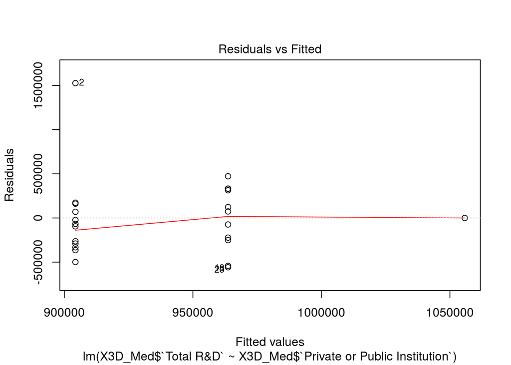

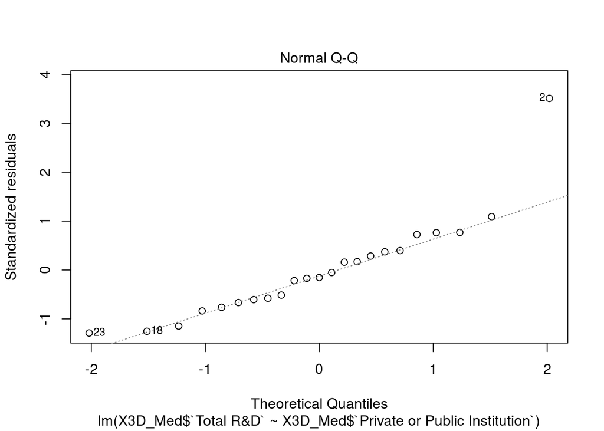

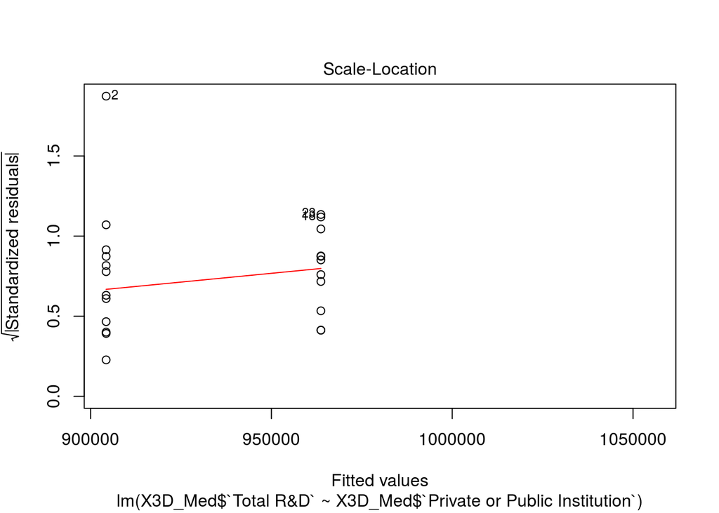

```r
plot(lm1b)
```

[figure not shown]

```r
abline()
```

```r
lm2<-lm (X3D_Med$`No. of med students`~ X3D_Med$`Private or Public Institution`)
summary(lm2)
```

```
##
## Call:
## lm(formula = X3D_Med$`No. of med students` ~ X3D_Med$`Private or Public Institution`)
##
## Residuals:
##     Min      1Q  Median      3Q     Max
## -286.00 -101.08  -25.33   73.25  393.00
##
## Coefficients:
##                                                 Estimate Std. Error t value
## (Intercept)                                       571.33      49.04  11.651
## X3D_Med$`Private or Public Institution`Private    -85.33     176.80  -0.483
## X3D_Med$`Private or Public Institution`Public      77.67      70.91   1.095
##                                                 Pr(>|t|)
## (Intercept)                                     1.25e-10 ***
## X3D_Med$`Private or Public Institution`Private     0.634
## X3D_Med$`Private or Public Institution`Public      0.286
## ---
## Signif. codes:  0 '***' 0.001 '**' 0.01 '*' 0.05 '.' 0.1 ' ' 1
##
## Residual standard error: 169.9 on 21 degrees of freedom
## Multiple R-squared:  0.07481,    Adjusted R-squared:  -0.0133
## F-statistic: 0.849 on 2 and 21 DF,  p-value: 0.442
```

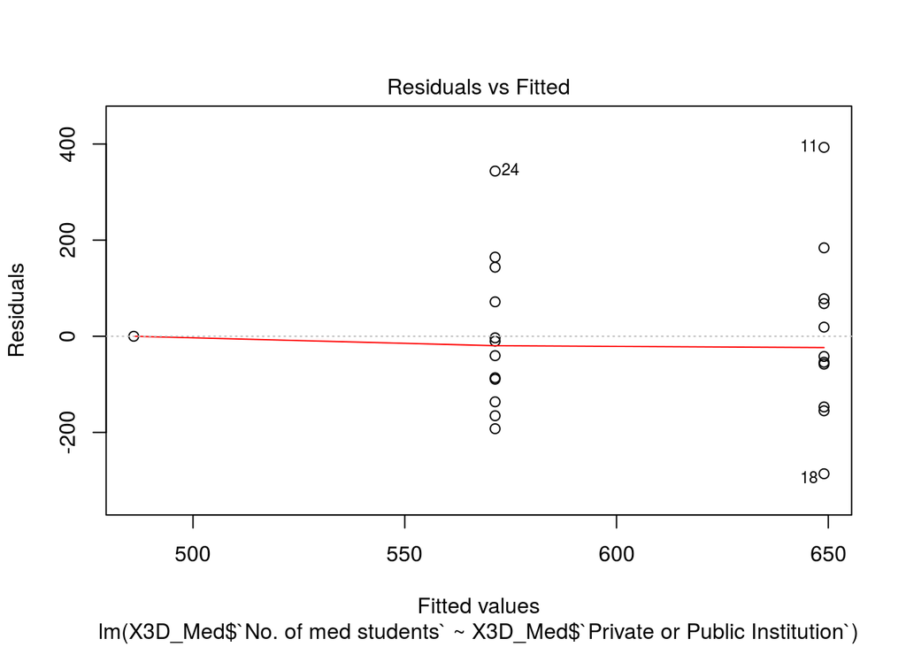

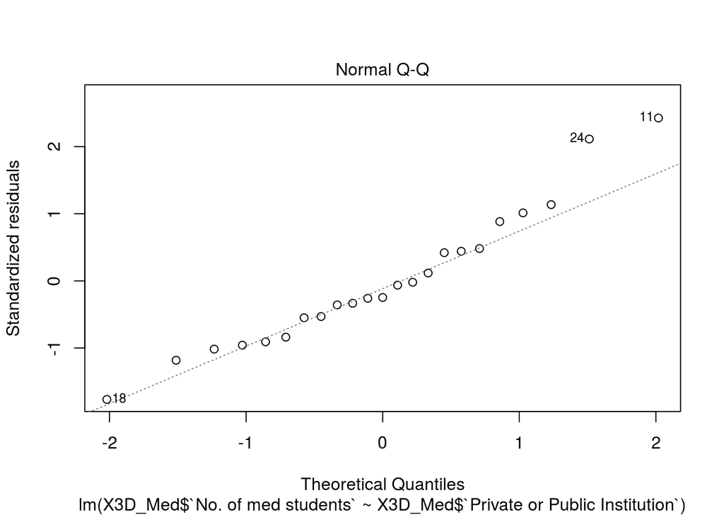

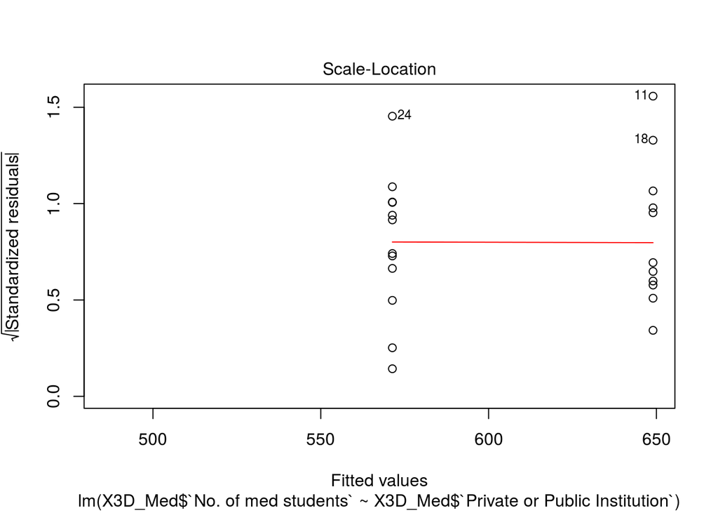

```r
plot(lm2)
```

[figure not shown]

```r
abline()
```

#MEDICAL COLLEGES AND 3D MEDICAL EDUCATION VISULIZATION

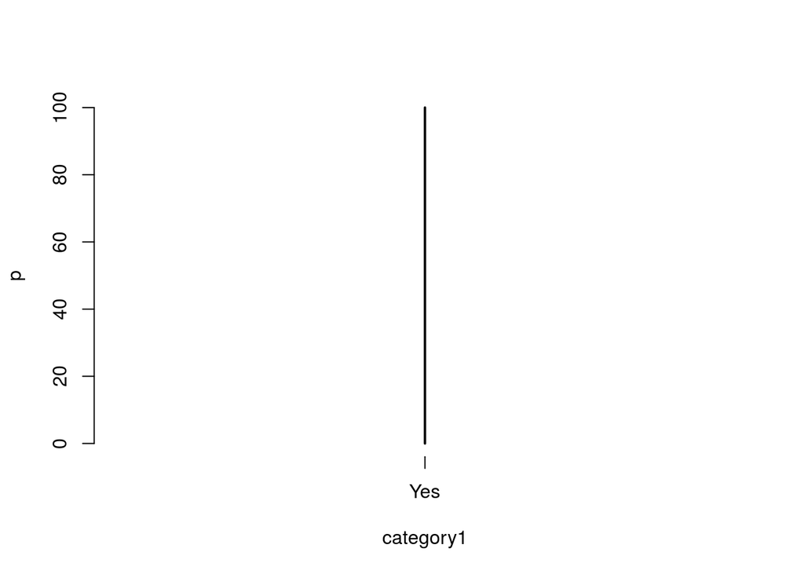

```
##     [,1] [,2] [,3]
## Yes   24  100    2
```

```r
CountPerc(X3D_Med$`Uses 3D Tech to treats mental diseases`)
```

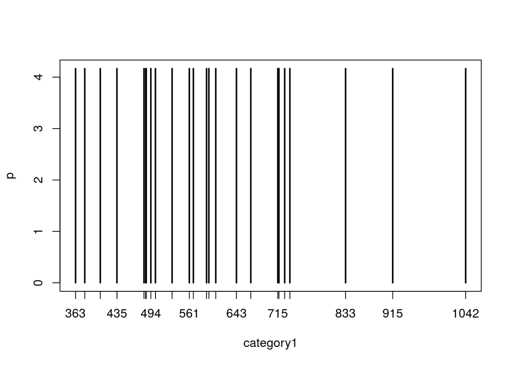

```
##      [,1]     [,2] [,3]
## 363     1 4.166667    2
## 379     1 4.166667    2
## 406     1 4.166667    2
## 435     1 4.166667    2
## 482     1 4.166667    2
## 485     1 4.166667    2
## 486     1 4.166667    2
## 494     1 4.166667    2
## 502     1 4.166667    2
## 531     1 4.166667    2
## 561     1 4.166667    2
## 568     1 4.166667    2
## 591     1 4.166667    2
## 595     1 4.166667    2
## 607     1 4.166667    2
## 643     1 4.166667    2
## 668     1 4.166667    2
## 715     1 4.166667    2
## 717     1 4.166667    2
## 727     1 4.166667    2
## 736     1 4.166667    2
## 833     1 4.166667    2
## 915     1 4.166667    2
## 1042    1 4.166667    2
```

```r
CountPerc(X3D_Med$`No. of med students`)
```

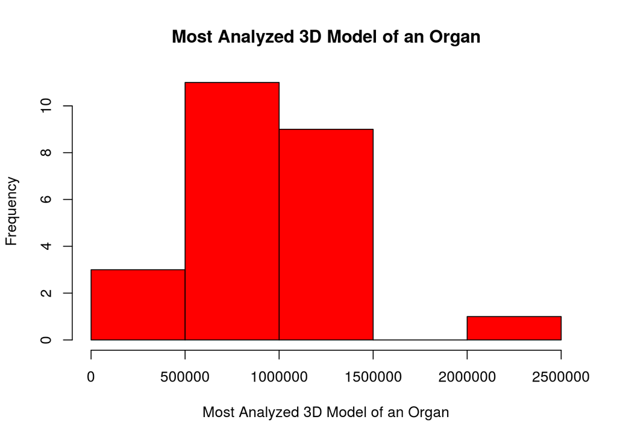

```
## MEDICAL COLLEGES AND 3D MEDICAL EDUCATION VISULIZATION.png has been saved in /home/rstudio-user
```

```r
plot3 <- function() {
        hist(X3D_Med$`Total R&D`, main = paste( "Most Analyzed 3D Model of an Organ"), col="red", xlab="Most Analyzed 3D Model of an Organ")
        dev.copy(png, file="MEDICAL COLLEGES AND 3D MEDICAL EDUCATION VISULIZATION.png", width=480, height=480)
        dev.off()
        cat("MEDICAL COLLEGES AND 3D MEDICAL EDUCATION VISULIZATION.png has been saved in", getwd())
}
plot3()
```

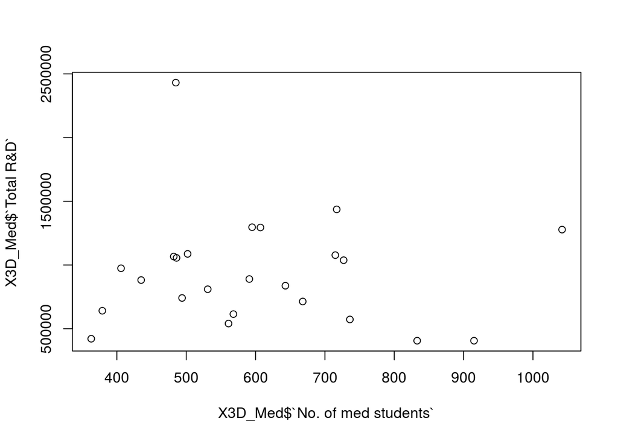

```r
plot(X3D_Med$`No. of med students`,X3D_Med$`Total R&D`)
```

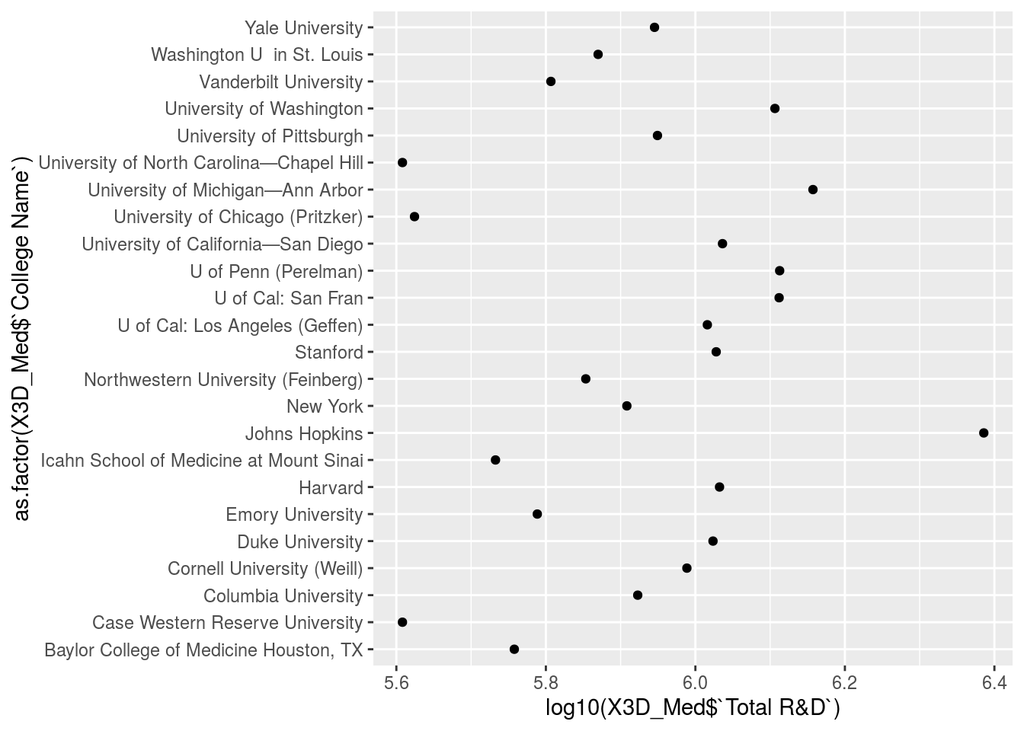

```r
qplot(y=as.factor(X3D_Med$`College Name`),x=log10(X3D_Med$`Total R&D`))
```

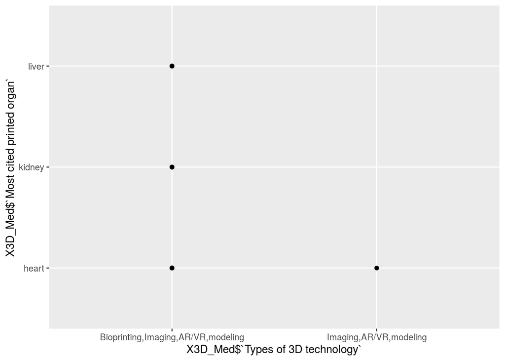

```r
qplot(X3D_Med$`Types of 3D technology`,X3D_Med$`Most cited printed organ`)
```

#GENERAL EXPOSURE TO 3D TECHNOLOGY  
General exposure to 3D Technology was gather by using a survey via google forums. It was administered to a class of students in a graduate Computer Science program. The survey was issued via a google forms to identify general exposure to 3D education. The participants represent a from a diverse background. Information gathered from participants included the region of high school, undergraduate institution and 3D technology of exposure , sentiments and among other entries. #GENERAL EXPOSURE TO 3D TECHNOLOGY Summary

```r
Descriptive_analysis(Class_Survey)
```

```
## Classes 'tbl_df', 'tbl' and 'data.frame':    149 obs. of  10 variables:
##  $ Decade of High school Graduation    : chr  "1980" "1980" "1980" "1980" ...
##  $ Region of High School               : chr  "Asia" "North America" "North America" "North America" ...
##  $ Decade of Undergraduate Graduation  : int  1980 1980 1980 1980 1980 1980 1980 1980 1990 1990 ...
##  $ Region of  Undergraduate            : chr  "Asia" "North America" "North America" "North America" ...
##  $ Department of  H.S. 3-D Exposure    : chr  "Science" "No exposure to 3-D education" "No exposure to 3-D education" "No exposure to 3-D education" ...
##  $ Was H.S. exposure beneficial        : chr  "Yes" "No exposure to 3-D education" "No exposure to 3-D education" "No exposure to 3-D education" ...
##  $ H.S. 3-D technology type            : chr  "3-D images" "No exposure to 3-D education" "No exposure to 3-D education" "No exposure to 3-D education" ...
##  $ Department of Undergraduate exposure: chr  "Science" "Science" "No exposure to 3-D education" "No exposure to 3-D education" ...
##  $ Was Undegrad exposure beneficial    : chr  "Yes" "Yes" "No exposure to 3-D education" "No exposure to 3-D education" ...
##  $ Undegraduate 3-D technology type    : chr  "3-D design" "3-D design" "No exposure to 3-D education" "No exposure to 3-D education" ...
##  - attr(*, "spec")=List of 2
##   ..$ cols   :List of 10
##   .. ..$ Decade of High school Graduation    : list()
##   .. .. ..- attr(*, "class")= chr  "collector_character" "collector"
##   .. ..$ Region of High School               : list()
##   .. .. ..- attr(*, "class")= chr  "collector_character" "collector"
##   .. ..$ Decade of Undergraduate Graduation  : list()
##   .. .. ..- attr(*, "class")= chr  "collector_integer" "collector"
##   .. ..$ Region of  Undergraduate            : list()
##   .. .. ..- attr(*, "class")= chr  "collector_character" "collector"
##   .. ..$ Department of  H.S. 3-D Exposure    : list()
##   .. .. ..- attr(*, "class")= chr  "collector_character" "collector"
##   .. ..$ Was H.S. exposure beneficial        : list()
##   .. .. ..- attr(*, "class")= chr  "collector_character" "collector"
##   .. ..$ H.S. 3-D technology type            : list()
##   .. .. ..- attr(*, "class")= chr  "collector_character" "collector"
##   .. ..$ Department of Undergraduate exposure: list()
##   .. .. ..- attr(*, "class")= chr  "collector_character" "collector"
##   .. ..$ Was Undegrad exposure beneficial    : list()
##   .. .. ..- attr(*, "class")= chr  "collector_character" "collector"
##   .. ..$ Undegraduate 3-D technology type    : list()
##   .. .. ..- attr(*, "class")= chr  "collector_character" "collector"
##   ..$ default: list()
##   .. ..- attr(*, "class")= chr  "collector_guess" "collector"
##   ..- attr(*, "class")= chr "col_spec"
```

```
##  [1] "Decade of High school Graduation"
##  [2] "Region of High School"
##  [3] "Decade of Undergraduate Graduation"
##  [4] "Region of  Undergraduate"
##  [5] "Department of  H.S. 3-D Exposure"
##  [6] "Was H.S. exposure beneficial"
##  [7] "H.S. 3-D technology type"
##  [8] "Department of Undergraduate exposure"
##  [9] "Was Undegrad exposure beneficial"
## [10] "Undegraduate 3-D technology type"
```

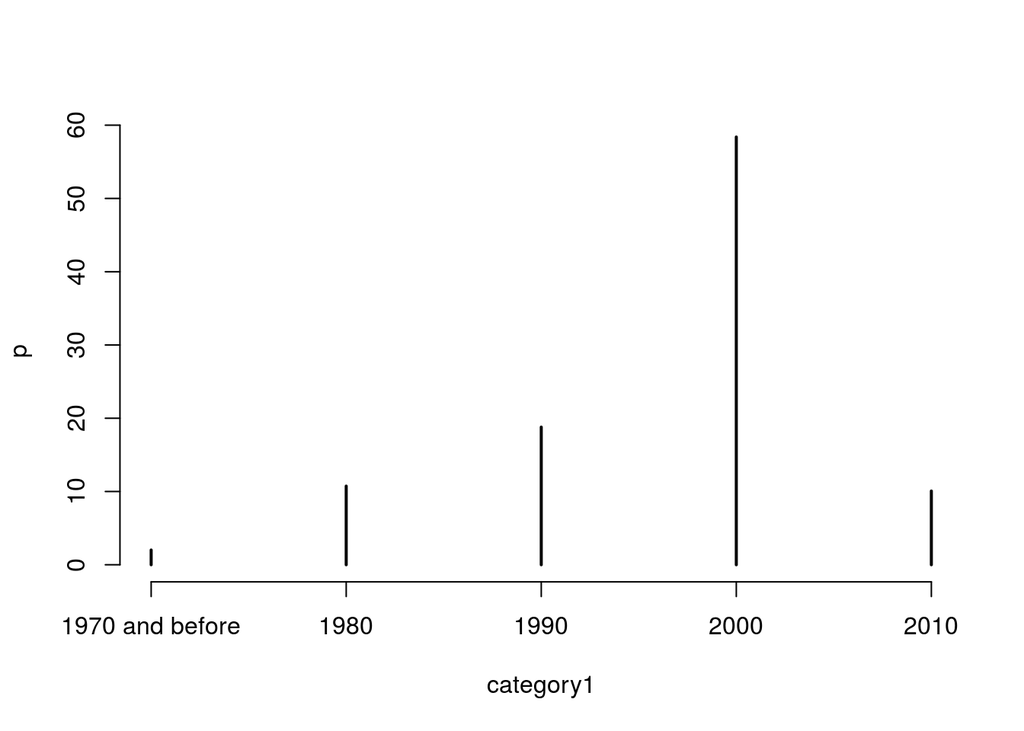

```
##                 [,1]      [,2] [,3]
## 1970 and before    3  2.013423    2
## 2010              15 10.067114    2
## 1980              16 10.738255    2
## 1990              28 18.791946    2
## 2000              87 58.389262    2
```

```r
CountPerc(Class_Survey$`Decade of High school Graduation`)
```

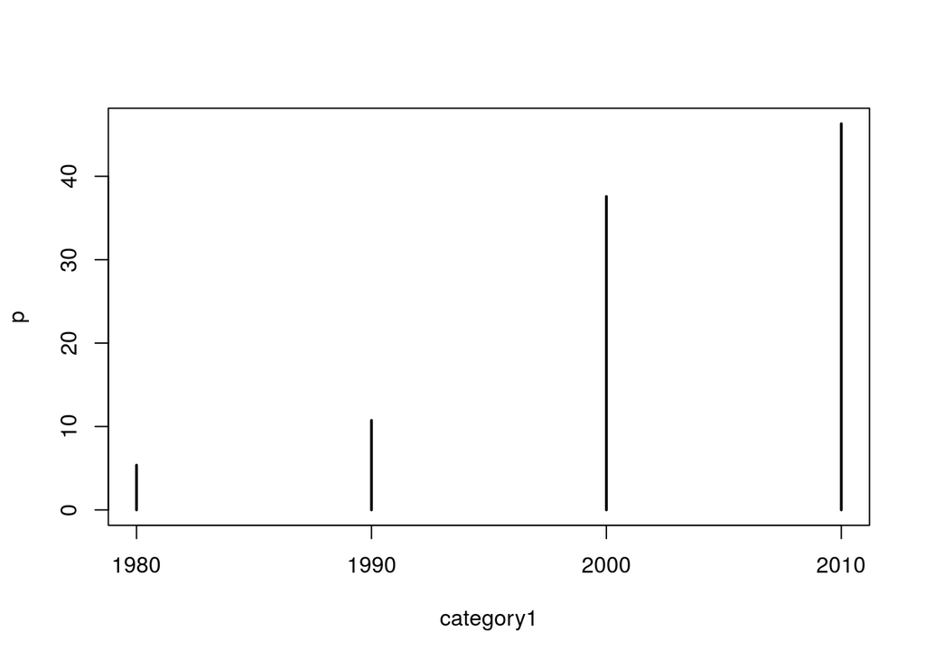

```
##      [,1]      [,2] [,3]
## 1980    8  5.369128    2
## 1990   16 10.738255    2
## 2000   56 37.583893    2
## 2010   69 46.308725    2
```

```r
CountPerc(Class_Survey$`Decade of Undergraduate Graduation`)
```

```r
# Investigate the distribution of 3d exposure by decades

Two_way_tables(Class_Survey$`Decade of High school Graduation`,Class_Survey$`H.S. 3-D technology type`)
```

```
##                     X^2 df P(> X^2)
## Likelihood Ratio 22.280 24  0.56254
## Pearson          21.656 24  0.59976
##
## Phi-Coefficient   : NA
## Contingency Coeff.: 0.356
## Cramer's V        : 0.191
```

```r
Two_way_tables(Class_Survey$`Decade of High school Graduation`,Class_Survey$`H.S. 3-D technology type`)
```

```
##                     X^2 df P(> X^2)
## Likelihood Ratio 22.280 24  0.56254
## Pearson          21.656 24  0.59976
##
## Phi-Coefficient   : NA
## Contingency Coeff.: 0.356
## Cramer's V        : 0.191
```

#GENERAL EXPOSURE TO 3D TECHNOLOGY STATISTICS AND MODELING

```r
Two_way_tables(Class_Survey$`Decade of High school Graduation`,Class_Survey$`Department of  H.S. 3-D Exposure`)
```

```
##                     X^2 df P(> X^2)
## Likelihood Ratio 17.183 20  0.64109
## Pearson          18.710 20  0.54076
##
## Phi-Coefficient   : NA
## Contingency Coeff.: 0.334
## Cramer's V        : 0.177
```

```r
Descriptive_analysis(Class_Survey)
```

[output not shown]

```
##  [1] "Decade of High school Graduation"
##  [2] "Region of High School"
##  [3] "Decade of Undergraduate Graduation"
##  [4] "Region of  Undergraduate"
##  [5] "Department of  H.S. 3-D Exposure"
##  [6] "Was H.S. exposure beneficial"
##  [7] "H.S. 3-D technology type"
##  [8] "Department of Undergraduate exposure"
##  [9] "Was Undegrad exposure beneficial"
## [10] "Undegraduate 3-D technology type"
```

#GENERAL EXPOSURE TO 3D TECHNOLOGY VISULIZATION

[figure not shown]

```r
ggplot(Class_Survey, aes(group=Class_Survey$`Decade of High school Graduation`, x=Class_Survey$`Region of High School`)) +geom_bar(aes(fill=Class_Survey$`Decade of High school Graduation`))+scale_x_discrete(breaks=levels(Class_Survey$`Region of High School`))+ggtitle("Participant count by H.S. Region and Gradutaion Decade")
```

```r
head(Class_Survey)
```

| Decade of High school Graduation | Region of High School | Decade of Undergraduate Graduation | Region of Undergraduate | Department of H.S. 3-D Exposure | Was H.S. exposure beneficial | H.S. 3-D technology type | Department of Undergraduate exposure | Was Undegrad exposure beneficial | Undegraduate 3-D technology type |
| --- | --- | --- | --- | --- | --- | --- | --- | --- | --- |
| 1980 | Asia | 1980 | Asia | Science | Yes | 3-D images | Science | Yes | 3-D design |
| 1980 | North America | 1980 | North America | No exposure to 3-D education | No exposure to 3-D education | No exposure to 3-D education | Science | Yes | 3-D design |
| 1980 | North America | 1980 | North America | No exposure to 3-D education | No exposure to 3-D education | No exposure to 3-D education | No exposure to 3-D education | No exposure to 3-D education | No exposure to 3-D education |
| 1980 | North America | 1980 | North America | No exposure to 3-D education | No exposure to 3-D education | No exposure to 3-D education | No exposure to 3-D education | No exposure to 3-D education | No exposure to 3-D education |
| 1980 | North America | 1980 | North America | No exposure to 3-D education | No exposure to 3-D education | No exposure to 3-D education | No exposure to 3-D education | No exposure to 3-D education | No exposure to 3-D education |
| 1970 and before | Europe | 1980 | Europe | No exposure to 3-D education | No exposure to 3-D education | No exposure to 3-D education | Math | Yes | 3-D images |

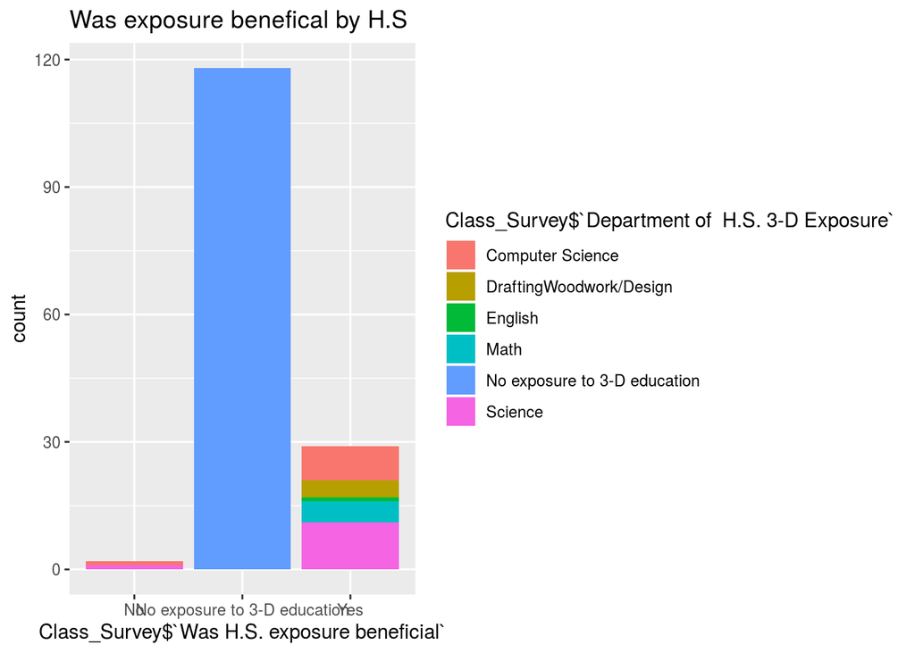

```r
ggplot(Class_Survey, aes( x=Class_Survey$`Was H.S. exposure beneficial`)) +geom_bar(aes(fill=Class_Survey$`Department of  H.S. 3-D Exposure`))+ggtitle("Was exposure benefical by H.S")
```

[figure not shown]

```r
ggplot(Class_Survey, aes( x=Class_Survey$`Was Undegrad exposure beneficial`)) +geom_bar(aes(fill=Class_Survey$`Department of Undergraduate exposure`))+scale_x_discrete(breaks=levels(Class_Survey$`Region of  Undergraduate`))+ggtitle("Was exposure benefical by Undergrad Region and Gradutaion ")
```

```r
#Remove no exposure

no_exposure_hs<-Class_Survey$`Department of  H.S. 3-D Exposure`[Class_Survey$`Department of  H.S. 3-D Exposure`  !="No exposure to 3-D education"]
no_exposure_hs2<-Class_Survey$`Was H.S. exposure beneficial`[Class_Survey$`Was H.S. exposure beneficial`  !="No exposure to 3-D education"]

no_exposure_hs2[no_exposure_hs2 == "Yes"]<-1

no_exposure_hs2[no_exposure_hs2 == "No"]<-0
no_exposure_hs3<-Class_Survey$`H.S. 3-D technology type`[Class_Survey$`H.S. 3-D technology type`!="No exposure to 3-D education"]

noexposure<-cbind(no_exposure_hs,no_exposure_hs2,no_exposure_hs3)

head(noexposure)
```

```
##      no_exposure_hs            no_exposure_hs2 no_exposure_hs3
## [1,] "Science"                 "1"             "3-D images"
## [2,] "DraftingWoodwork/Design" "1"             "3-D design"
## [3,] "Math"                    "1"             "3-D images"
## [4,] "DraftingWoodwork/Design" "1"             "3-D design"
## [5,] "Math"                    "1"             "3-D images"
## [6,] "Computer Science"        "1"             "3-D digital Modeling"
```

#IMPACT OF USING 3D ANATOMICAL REPRESENTATIONS IN MEDICAL EDUCATION The participants were from Medicine, Kinesiology, allied health schools: Health Sciences,Massage therapy,Occupational therapy, Physiotherapy,Psychology, and Social science, Some studies had participants from 2 or more institutes, or from several schools. The dataset reflect to record Major features, year of study, type of study, 3D tools used, institution of study,author,outcome of study and learning knowledge.

```r
Descriptive_analysis(Impact3D)
```

```
## Classes 'tbl_df', 'tbl' and 'data.frame':    30 obs. of  14 variables:
##  $ University/Hospital                                                          : chr  "McMaster University" "McGill University" "Université Claude Bernard Lyon" "Des Moines University" ...
##  $ Country                                                                      : chr  "Canada" "Canada" "France" "USA" ...
##  $ Type of study                                                                : chr  "Randomized controlled study" "Randomized controlled study" "Randomized controlled study" "Randomized controlled study" ...
##  $ Number of Participants                                                       : int  87 60 184 16 120 76 89 53 70 165 ...
##  $ Number of Groups per study                                                   : int  2 2 2 1 1 2 2 2 2 2 ...
##  $ Pre Med or Medical Student  or Other:Psych,Dental,Massage Therapy, Kineselogy: chr  "Pre Med" "Medical Student" "Pre Med" "Pre med" ...
##  $ Author                                                                       : chr  "Garg" "Nicholson" "Guillot" "Hisley" ...
##  $ Year                                                                         : int  2002 2006 2007 2008 2007 2008 2009 2009 2009 2010 ...
##  $ Outcome in favor of usage of 3D tech                                         : chr  "negative" "positive" "neutral" "positive" ...
##  $ Technology                                                                   : chr  "3D anatomy model" "3D anatomy model" "Spatial visualization model,3D anatomy model" "3D Imagery,3D anatomy model" ...
##  $ Results/limitations                                                          : chr  "Certain key or canonical viewpoints of an object are critically important for spatial learning. Multiple orient"| __truncated__ "The intervention group’s mean on the quiz was higher than the mean score for the…
##  $ What was carried out/measured                                                : chr  "Students were allocated to either multiple-view (MV) group (any of 36 possible angles) of rotation or a key-vie"| __truncated__ "The intervention group completed a Web-based tutorial on ear anatomy that includ…
##  $ Highest knowledge level of medical VR application                            : chr  "Level 2" "Level 2" "Level 1" "Level 3" ...
##  $ Major Features/requirements                                                  : chr  "Human data form model,interaction" "Human data form model,interaction" "Visualization,Human data form model ,interaction" "Visualization ,Human data form model,interaction" ...
##  - attr(*, "spec")=List of 2
##   ..$ cols   :List of 14
##   .. ..$ University/Hospital                                                          : list()
##   .. .. ..- attr(*, "class")= chr  "collector_character" "collector"
##   .. ..$ Country                                                                      : list()
##   .. .. ..- attr(*, "class")= chr  "collector_character" "collector"
##   .. ..$ Type of study                                                                : list()
##   .. .. ..- attr(*, "class")= chr  "collector_character" "collector"
##   .. ..$ Number of Participants                                                       : list()
##   .. .. ..- attr(*, "class")= chr  "collector_integer" "collector"
##   .. ..$ Number of Groups per study                                                   : list()
##   .. .. ..- attr(*, "class")= chr  "collector_integer" "collector"
##   .. ..$ Pre Med or Medical Student  or Other:Psych,Dental,Massage Therapy, Kineselogy: list()
##   .. .. ..- attr(*, "class")= chr  "collector_character" "collector"
##   .. ..$ Author                                                                       : list()
##   .. .. ..- attr(*, "class")= chr  "collector_character" "collector"
##   .. ..$ Year                                                                         : list()
##   .. .. ..- attr(*, "class")= chr  "collector_integer" "collector"
##   .. ..$ Outcome in favor of usage of 3D tech                                         : list()
##   .. .. ..- attr(*, "class")= chr  "collector_character" "collector"
##   .. ..$ Technology                                                                   : list()
##   .. .. ..- attr(*, "class")= chr  "collector_character" "collector"
##   .. ..$ Results/limitations                                                          : list()
##   .. .. ..- attr(*, "class")= chr  "collector_character" "collector"
##   .. ..$ What was carried out/measured                                                : list()
##   .. .. ..- attr(*, "class")= chr  "collector_character" "collector"
##   .. ..$ Highest knowledge level of medical VR application                            : list()
##   .. .. ..- attr(*, "class")= chr  "collector_character" "collector"
##   .. ..$ Major Features/requirements                                                  : list()
##   .. .. ..- attr(*, "class")= chr  "collector_character" "collector"
##   ..$ default: list()
##   .. ..- attr(*, "class")= chr  "collector_guess" "collector"
##   ..- attr(*, "class")= chr "col_spec"
```

```
##  [1] "University/Hospital"
##  [2] "Country"
##  [3] "Type of study"
##  [4] "Number of Participants"
##  [5] "Number of Groups per study"
##  [6] "Pre Med or Medical Student  or Other:Psych,Dental,Massage Therapy, Kineselogy"
##  [7] "Author"
##  [8] "Year"
##  [9] "Outcome in favor of usage of 3D tech"
## [10] "Technology"
## [11] "Results/limitations"
## [12] "What was carried out/measured"
## [13] "Highest knowledge level of medical VR application"
## [14] "Major Features/requirements"
```

```r
Descriptive_analysis(Impact3D$`Type of study`)
```

```
##  chr [1:30] "Randomized controlled study" "Randomized controlled study" ...
```

```r
cor(Impact3D$`Number of Participants`,Impact3D$`Number of Groups per study`)
```

```
## [1] 0.03796097
```

```r
Descriptive_analysis(Impact3D)
```

[output not shown]

```
##  [1] "University/Hospital"
##  [2] "Country"
##  [3] "Type of study"
##  [4] "Number of Participants"
##  [5] "Number of Groups per study"
##  [6] "Pre Med or Medical Student  or Other:Psych,Dental,Massage Therapy, Kineselogy"
##  [7] "Author"
##  [8] "Year"
##  [9] "Outcome in favor of usage of 3D tech"
## [10] "Technology"
## [11] "Results/limitations"
## [12] "What was carried out/measured"
## [13] "Highest knowledge level of medical VR application"
## [14] "Major Features/requirements"
```

```r
cor(Impact3D$`Number of Participants`,Impact3D$`Number of Groups per study`)
```

```
## [1] 0.03796097
```

```r
result_outcome_model=lm(Impact3D$`Number of Groups per study`~.,Impact3D)
anova(result_outcome_model)
```

|  | Df | Sum Sq | Mean Sq | F value | Pr(>F) |
| --- | --- | --- | --- | --- | --- |
| `University/Hospital` | 22 | 8.1379310 | 0.3699060 | NaN | NaN |
| `Type of study` | 3 | 3.0000000 | 1.0000000 | NaN | NaN |
| `Number of Participants` | 1 | 0.1305074 | 0.1305074 | NaN | NaN |
| `Pre Med or Medical Student or Other:Psych,Dental,Massage Therapy, Kineselogy` | 1 | 0.7752530 | 0.7752530 | NaN | NaN |
| Author | 1 | 0.0942396 | 0.0942396 | NaN | NaN |
| Residuals | 0 | 0.0000000 | NaN | NA | NA |